# FigureYa246supervisedGDSC

Xiaofan Lu

2025-5-20

# Academic Citation

If you use this code in your work or research, we kindly request that you cite our publication:

Xiaofan Lu, et al. (2025). FigureYa: A Standardized Visualization Framework for Enhancing Biomedical Data Interpretation and Research Efficiency. iMetaMed. https://doi.org/10.1002/imm3.70005

# 需求描述

想实现图5A B, 首先对TCGA数据集进行聚类分析，之后将GDSC细胞系按照TCGA聚类结果进行分组，分组后比较分组的药物敏感性，用AUC定量分析。

To crowdsource Figure 5A and B: first perform clustering on the TCGA dataset; then group GDSC cell lines according to the TCGA clustering results; after grouping, compare drug sensitivity between groups using AUC for quantitative analysis.

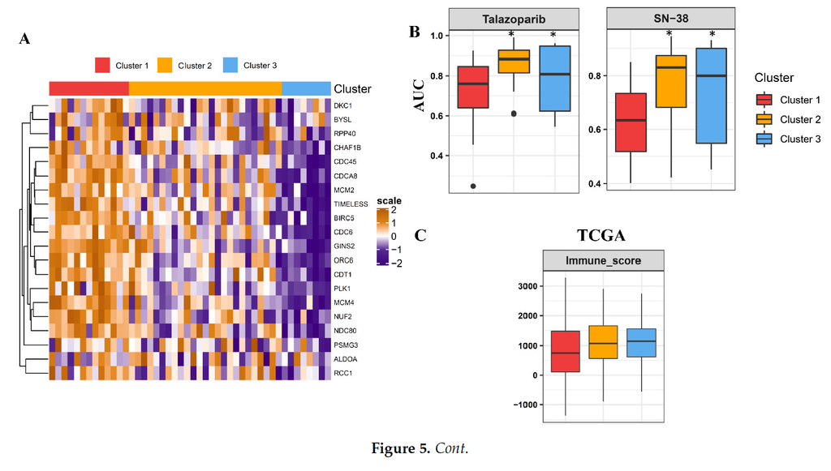

出自https://www.mdpi.com/2072-6694/13/9/2128 Fromhttps://www.mdpi.com/2072-6694/13/9/2128

Figure 5. Drug discovery and immune characterization in essential gene-classified clusters of lung adenocarcinoma (LUAD). (A) Heatmap showing essential gene-stratified-clusters exhibiting distinct expressions in GDSC lung cancer cells. (B) Drug response area under the receiver operator characteristics curve (AUC) of SN-38 and talazoparib within essential geneclassified clusters demonstrated as a boxplot.

To identify **drugs** that exhibited distinct **efficacy in essential gene-classified clusters**, the prediction model was applied to the GDSC database (Figure 5A). Areas under the receiver operator characteristics curve (AUC) of drug responses within clusters were compared. Totally, the GDSC database contains 367 compounds. Only 257 compounds which were tested on more than 75% of the LUAD cell lines were used for analyses (Tables S8 and S9). AUCs of **SN-38, a topoisomerase I inhibitor, and talazoparib, a poly(ADP ribose) polymerase (PARP) inhibitor, were significantly lower in cluster 1 LUAD cells** (Figure 5B). This suggested that cluster 1 tumors with highly proliferative signatures were vulnerable to drugs targeting DNA-replication mechanisms.

# 应用场景

> 这又有什么意义呢？能指导临床吗？ What’s the significance? Can it guide clinical practice?

这次从TCGA表达谱分出的亚型推演到GDSC数据库里的细胞系，由此推出各亚型的药物敏感性。 This time, subtypes derived from the TCGA expression profile are extrapolated to GDSC cell lines, thereby inferring drug sensitivity for each subtype.

# 环境设置

```r
source("install_dependencies.R")
```

[output not shown]

[output not shown]

[output not shown]

[output not shown]

[output not shown]

[output not shown]

```r
library(pheatmap)
library(data.table)
library(ConsensusClusterPlus)
library(ComplexHeatmap)
```

[output not shown]

```r
library(lolR)
```

```r
library(impute)
library(ggplot2)
library(ggpubr)
Sys.setenv(LANGUAGE = "en") #显示英文报错信息
options(stringsAsFactors = FALSE) #禁止chr转成factor
```

自定义函数 Custom function

```r
standarize.fun <- function(indata=NULL, halfwidth=NULL, centerFlag=T, scaleFlag=T) {
  outdata=t(scale(t(indata), center=centerFlag, scale=scaleFlag))
  if (!is.null(halfwidth)) {
    outdata[outdata>halfwidth]=halfwidth
    outdata[outdata<(-halfwidth)]= -halfwidth
  }
  return(outdata)
}
```

# 输入文件

TCGA-LUAD.htseq_fpkm.tsv.gz，TCGA-LUAD的表达谱数据以及基因注释，源于https://xenabrowser.net/datapages/?dataset=TCGA-LUAD.htseq_fpkm.tsv&host=https%3A%2F%2Fgdc.xenahubs.net&removeHub=https%3A%2F%2Fxena.treehouse.gi.ucsc.edu%3A443

细胞系数据下载自DepMap，https://depmap.org/portal/download/： Cell line data downloaded from DepMap:

- CCLE_RNAseq_rsem_genes_tpm_20180929.txt.gz，细胞系表达谱数据，源于https://depmap.org/portal/download/api/download?file_name=ccle%2Fccle_2019%2FCCLE_RNAseq_rsem_genes_tpm_20180929.txt.gz&bucket=depmap-external-downloads
- Cell_lines_annotations_20181226.txt，细胞系信息数据，源自https://depmap.org/portal/download/api/download?file_name=ccle%2Fccle_2019%2FCell_lines_annotations_20181226.txt&bucket=depmap-external-downloads
- sanger-dose-response.csv，GDSC细胞系药物敏感性数据源自https://depmap.org/portal/download/api/download?file_name=processed_portal_downloads%2Fgdsc-drug-set-export-658c.5%2Fsanger-dose-response.csv&bucket=depmap-external-downloads

```r
# 加载TCGA-LUAD数据并处理
# Load and process TCGA-LUAD data
luad.expr <- fread("TCGA-LUAD.htseq_fpkm.tsv.gz",sep = "\t",check.names = F,stringsAsFactors = F,header = T,data.table = F)
rownames(luad.expr) <- luad.expr$Ensembl_ID;
luad.expr <- luad.expr[,setdiff(colnames(luad.expr),"Ensembl_ID")]
Ginfo <- read.delim("gencode.v22.annotation.gene.probeMap",sep = "\t",row.names = 1,check.names = F,stringsAsFactors = F,header = T)

comgene <- intersect(rownames(luad.expr),rownames(Ginfo)) # 取出表达谱和基因注释的相同基因
# Intersect genes between expression and gene annotation
luad.expr <- luad.expr[comgene,]
Ginfo <- Ginfo[comgene,]
luad.expr$gene <- Ginfo$gene
luad.expr <- luad.expr[!duplicated(luad.expr$gene),]; rownames(luad.expr) <- luad.expr$gene; luad.expr <- luad.expr[,setdiff(colnames(luad.expr),"gene")] # 去重
# Remove duplicates by gene symbol

tumsam <- colnames(luad.expr)[substr(colnames(luad.expr),14,16) == "01A"] # 提取TCGA-LUAD的肿瘤样本
# Extract TCGA-LUAD tumor samples
```

# TCGA数据分型 - 无监督共识聚类 TCGA Data Typing - Unsupervised Consensus Clustering

使用原文定义的36个essential genes（筛选基因的方法可参考FigureYa240CRISPR），为TCGA的patient进行无监督共识聚类（consensus clustering），这里分成3个亚型，然后画个热图看效果。 Using the 36 essential genes defined in the original paper (see FigureYa240CRISPR for the selection method), perform unsupervised consensus clustering on TCGA patients into 3 subtypes, then plot a heatmap to visualize.

```r
# 设置颜色 | set colors
red <- "#E53837"
blue <- "#6AADF0"
yellow <- "#F7A400"
heatmap.BLYW <- c("#3F047D","white","#B05900")

genes <- c("NUF2","GINS1","TOP2A","CDC6","NDC80","RRM2",
           "CCNA2","KIF11","PRC1","BUB1B","CDCA8","TPX2",
           "PLK1","CDC45","CDC20","BIRC5","ECT2","PCNA",
           "CHAF1B","TIMELESS","GINS2","ORC6","CDT1","MCM2",
           "MCM4","RCC1","BOP1","ALDOA","PSMG3","DKC1",
           "HSPD1","BYSL","RPP40","SNRPE","HSPE1","CCT3")

indata <- luad.expr[genes,tumsam]
cc <- ConsensusClusterPlus(d = as.matrix(indata),
                           maxK = 3, # 最大3类 | maximum K=3
                           reps = 1000, # 1000次扰动 | 1000 permutations
                           pItem = 0.95, # 每次对基因进行95%重抽样 | 95% resampling of genes each iteration
                           clusterAlg = "pam", # 采用PAM算法 | use PAM
                           seed = 19991018,
                           title = ".",
                           plot = "pdf")
```

```
## end fraction
```

```
## clustered
## clustered
```

```r
group <- paste0("Cluster",cc[[3]]$consensusClass); names(group) <- tumsam # 取出三个亚型的结果 | retrieve 3-cluster labels
group <- sort(group) # 按照类排序 | sort by cluster
```

画个热图看分型效果 Draw a heatmap to inspect subtype separation

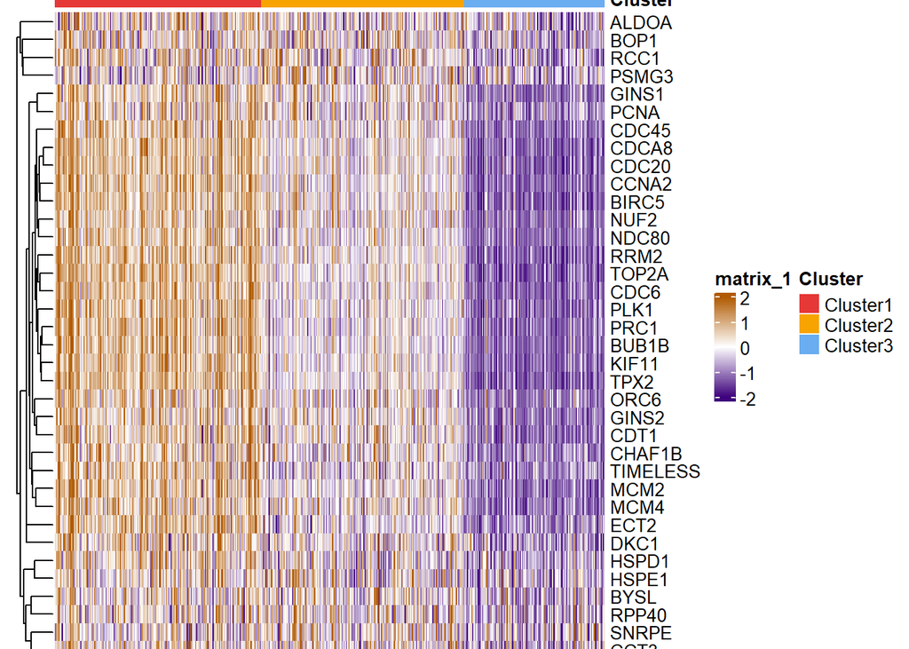

[figure not shown]

```r
plotdata <- standarize.fun(indata[,names(group)],halfwidth = 2) # 绘图数据标准化（z-score并将绝对值超过2的数值截断） | z-score and cap at |2|

annCol.tcga <- data.frame(Cluster = as.character(group), # 构建样本注释 | build sample annotation
                          row.names = names(group),
                          stringsAsFactors = F)
annColors <- list("Cluster" = c("Cluster1" = red,"Cluster2" = yellow,"Cluster3" = blue)) # 构建颜色注释 | annotation colors

# 绘制热图 | draw heatmap
pheatmap(plotdata,
         color = NMF:::ccRamp(x = heatmap.BLYW,n=64) , # 原文颜色模版 | color scheme as in paper
         annotation_col = annCol.tcga[colnames(plotdata),,drop = F],
         annotation_colors = annColors,
         cluster_cols = FALSE, # 样本不聚类，按照亚型顺序排列 | keep TCGA columns ordered by subtype
         cluster_rows = TRUE, # 行聚类 | cluster rows
         border_color = NA,
         treeheight_row = 20, # 修改行树高 | row dendrogram height
         cellheight = 10, # 修改每个单元的高度 | cell height
         cellwidth = 0.6, # 修改每个单元的宽度 | cell width
         show_rownames = TRUE, # 显示行名 | show rownames
         show_colnames = FALSE, # 不显示列名 | hide colnames
         filename = "heatmap of essential genes in tcga luad.pdf")
```

细胞系数据处理 Cell Line Data Processing 筛选出同时具有药敏数据和表达数据的LUAD细胞系 Select LUAD cell lines that have both drug sensitivity and expression data

```r
## 读取细胞系注释文件 | read cell line annotations
ccle.anno <- read.delim("Cell_lines_annotations_20181226.txt",sep = "\t",row.names = 1,check.names = F,stringsAsFactors = F,header = T)
ccle.anno <- ccle.anno[which(ccle.anno$tcga_code == "LUAD" & ccle.anno$Hist_Subtype1 == "adenocarcinoma"),] # 选取LUAD并且病理亚型为腺癌的样本（和原文的数量有些出入，也许是我对病理亚型理解不到位） | select LUAD and adenocarcinoma subtype (counts may differ from paper)

## 读取细胞系药敏并匹配DepmapID | read drug sensitivity and match DepMap IDs
gdsc <- fread("sanger-dose-response.csv",check.names = F,stringsAsFactors = F,header = T,data.table = F)
gdsc <- gdsc[,c("ARXSPAN_ID","DRUG_NAME","AUC_PUBLISHED")] # 提取细胞系的DepmapID（细胞系编号），药物名以及对应AUC值 | extract DepMap ID, drug name, and AUC
gdsc.auc <- reshape(gdsc, idvar = "ARXSPAN_ID", timevar = "DRUG_NAME", direction = "wide") # 将long型数据转换为wide型数据 | long-to-wide
rownames(gdsc.auc) <- gdsc.auc$ARXSPAN_ID; gdsc.auc <- gdsc.auc[,-1]
colnames(gdsc.auc) <- gsub("AUC_PUBLISHED.","",colnames(gdsc.auc),fixed = T) # 生成行为细胞系，列为药物，入值为AUC的矩阵 | matrix rows=cell lines, cols=drugs

comdep <- intersect(rownames(gdsc.auc),ccle.anno$depMapID) # 取出有药敏并且为LUAD的细胞系 | LUAD lines with drug data
gdsc.auc <- gdsc.auc[comdep,]
rmdrug <- colnames(gdsc.auc)[apply(gdsc.auc,2, function(x) {sum(is.na(x)) > 0.10 * length(comdep)})] # 获得要去除的药物（去除药敏在大于10%的样本中药物（原文是25%）） | remove drugs missing in >10% lines (paper used 25%)
gdsc.auc <- gdsc.auc[,setdiff(colnames(gdsc.auc),rmdrug)]  # 去掉这些药物 | drop these drugs
gdsc.auc <- as.data.frame(impute.knn(t(gdsc.auc))$data) # 对剩余空值进行KNN填补 | KNN-impute remaining missing

index <- match(colnames(gdsc.auc),ccle.anno$depMapID) # 将DepmapID和细胞系名称匹配 | match DepMap IDs to line names
colnames(gdsc.auc) <- rownames(ccle.anno)[index] # 替换DepmapID | replace with line names

## 读取细胞系表达谱 | read cell line expression
ccle.expr <- fread("CCLE_RNAseq_rsem_genes_tpm_20180929.txt.gz",sep = "\t",check.names = F,stringsAsFactors = F,header = T,data.table = F)
rownames(ccle.expr) <- ccle.expr$gene_id
ccle.expr <- ccle.expr[,-c(1:2)]; rownames(ccle.expr) <- sapply(strsplit(rownames(ccle.expr),".",fixed = T),"[",1) # ENSEMBL ID的匹配 | harmonize Ensembl IDs
Ginfo2 <- Ginfo; rownames(Ginfo2) <- sapply(strsplit(rownames(Ginfo2),".",fixed = T), "[",1)
comgene <- intersect(rownames(ccle.expr),rownames(Ginfo2))
ccle.expr <- ccle.expr[comgene,]
Ginfo2 <- Ginfo2[comgene,]
ccle.expr$gene <- Ginfo2$gene
ccle.expr <- ccle.expr[!duplicated(ccle.expr$gene),]; rownames(ccle.expr) <- ccle.expr$gene; ccle.expr <- ccle.expr[,setdiff(colnames(ccle.expr),"gene")] # 去重 | remove duplicates by gene symbol

## 筛选同时具有药敏和表达的LUAD细胞系 | select LUAD lines with both drug and expression
comccle <- intersect(intersect(rownames(ccle.anno),colnames(ccle.expr)),colnames(gdsc.auc)) # 筛选同时具有表达和药敏的LUAD细胞系 | intersection across meta/expression/drug
comgene <- intersect(genes,rownames(ccle.expr))
ccle.expr <- log2(ccle.expr[comgene,comccle] + 1) # 表达谱取对数 | log2-transform expression
ccle.anno <- ccle.anno[comccle,]
```

# 构建nearest centroid classifier，给细胞系分型

Build nearest centroid classifier and assign cell line subtypes

构建nearest centroid classifier，然后用classifier预测GDSC细胞系数据，让细胞系按照TCGA分型结果分成对应的三组。 构建nearest centroid classifier，然后用classifier预测GDSC细胞系数据，让细胞系按照TCGA分型结果分成对应的三组。 Build a nearest centroid classifier from TCGA and use it to predict GDSC cell lines, assigning them to the three TCGA-derived groups.

```r
# 中位数中心化
#indata <- sweep(luad.expr[comgene,names(group)], 1, apply(luad.expr[comgene,names(group)], 1, median))
# 中位数中心化 | median-centering
#indata <- sweep(luad.expr[comgene,names(group)], 1, apply(luad.expr[comgene,names(group)], 1, median))
```

原文采用中心化来构建预测模型，但是我这里的结果不是很好，所以换用z-score标准化的结果。 The original paper used centering to build the classifier; results here were suboptimal, so z-score standardization was used instead.

```r
indata <- t(scale(t(luad.expr[comgene,names(group)]))) #z-score标准化 | z-score standardization

# 构建nearest centroid classifier | build nearest centroid classifier
classifier <- lol.classify.nearestCentroid(t(indata), as.numeric(factor(group)))

#testdata <- sweep(ccle.expr[comgene,], 1, apply(ccle.expr[comgene,], 1, median))
testdata <- t(scale(t(ccle.expr))) # z-score标准化测试集 | z-score the test set

# 在细胞系应用classifier | apply classifier to cell lines
ccle.group <- paste0("Cluster",predict(classifier, t(testdata))); names(ccle.group) <- colnames(testdata)
ccle.group <- sort(ccle.group) # 将预测的亚型排序 | sort predicted labels
```

画个热图看效果 Draw a heatmap to inspect the assignment

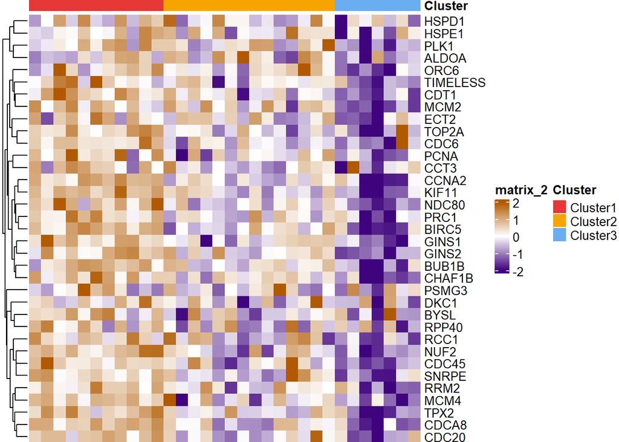

[figure not shown]

```r
plotdata <- standarize.fun(ccle.expr[,names(ccle.group)],halfwidth = 2) # 绘图数据标准化 | standardize for plotting

annCol.ccle <- data.frame(Cluster = as.character(ccle.group), # 构建细胞系的样本注释 | build cell line annotations
                          row.names = names(ccle.group),
                          stringsAsFactors = F)
pheatmap(plotdata,
         color = NMF:::ccRamp(x = heatmap.BLYW,n=64),
         annotation_col = annCol.ccle[colnames(plotdata),,drop = F],
         annotation_colors = annColors,
         cluster_cols = FALSE,
         cluster_rows = TRUE,
         border_color = NA,
         treeheight_row = 20,
         cellheight = 10,
         cellwidth = 10,
         show_rownames = TRUE,
         show_colnames = FALSE,
         filename = "heatmap of essential genes in ccle luad.pdf")
```

# 药物敏感性的Kruskal检验 Kruskal-Wallis test for drug sensitivity

计算GDSC细胞系各亚型对每种药物的敏感性，输出统计结果并画图。 Compute sensitivity per subtype for each drug, output stats, and plot.

由GDSC细胞系各亚型的敏感性结果可以反推出TCGA各亚型对药物对敏感性。 Sensitivity patterns in GDSC-assigned subtypes can be extrapolated back to TCGA subtypes.

```r
outTab <- NULL
for(drug in rownames(gdsc.auc)) {
  tmp <- data.frame(auc = as.numeric(gdsc.auc[drug,names(ccle.group)]),
                    group = as.character(ccle.group))
  avg <- with(tmp, tapply(auc, group, mean)) # 得到各亚型的AUC均值 | mean AUC per subtype
  kt <- kruskal.test(auc~group, data = tmp) # kruskal检验 | Kruskal-Wallis test
  outTab <- rbind.data.frame(outTab,
                             data.frame(drug = drug,
                                        avg1 = avg[1],
                                        avg2 = avg[2],
                                        avg3 = avg[3],
                                        pvalue = kt$p.value,
                                        stringsAsFactors = F),
                             stringsAsFactors = F)

  if(kt$p.value < 0.05) {
    message(drug," pass statistical significance...")

    # 将通过显著性检验的药物绘制箱型图 | plot boxplot for significant drugs
    p <- ggplot(tmp, aes(group, auc, fill=group)) +
      geom_boxplot(outlier.shape = NA) +
      geom_point(shape = 21, size=2,
                 position = position_jitterdodge(),
                 aes(color=group), alpha = 0.6) +
      scale_fill_manual(values = c(red,yellow,blue)) +
      scale_color_manual(values = c(red,yellow,blue)) +
      xlab(NULL) + ylab(paste0("AUC of ", drug)) +
      theme_bw() +
      theme(axis.text.x = element_blank(),
            axis.text.y = element_text(size = 10, color = "black"),
            axis.ticks.x = element_blank(),
            panel.background = element_blank(),
            panel.grid = element_blank(),
            legend.position = "right",
            legend.title = element_blank()) +
      stat_compare_means(method = "kruskal.test",
                         label.y = 0.98) # 根据自己的数据调整文字所在的位置，或者用AI等矢量图软件打开PDF文件，调整文字位置 | adjust label position as needed or later in a vector editor
    ggsave(filename = paste0("boxplot of estimated auc in ",drug,".pdf"),
           width = 4,height = 3.5)
  }
}
```

```
## QUIZARTINIB pass statistical significance...
```

```
## FR-180204 pass statistical significance...
```

```
## VENOTOCLAX, ABT-199, VENECLEXTA, GDC-0199 pass statistical significance...
```

```
## DOCETAXEL pass statistical significance...
```

```
## LESTAURTINIB pass statistical significance...
```

```
## BX-795 pass statistical significance...
```

```
## EHT 1864 pass statistical significance...
```

```
## FULVESTRANT pass statistical significance...
```

```
## EPZ004777 pass statistical significance...
```

```
## EPZ-5676 pass statistical significance...
```

```r
drugs <- outTab[outTab$pvalue < 0.05, "drug"]

write.table(outTab, file = "output_kruskal test of estimated auc among cell lines.txt",sep = "\t",row.names = F,col.names = T,quote = F)
```

[figure not shown]